# Differences between SAS and R - Survival Analysis

2021-07-12

# Survival analysis in clinical trials

The most commonly used survival methods in clinical trials are:

- Kaplan-Meier (KM) estimators - non-parametric statistics to estimate the survival function
- Log-rank test - non-parametric test to compare the survival functions of two or more groups
- Cox proportional hazards (PH) model - semi-parametric model, commonly used to assess the relationship between the survival time and explanatory variables
- Parametric model - occasionally used in the analysis of survival data, but widely used in health economic assessments to predict future survival trends based on observed data, or in simulations

There are also more complex models such as

- Accelarated failure time model
- Competing risk model
- Restricted mean survival time
- Time-dependent Cox model

Right now we will only focus on the differences identified from the four more commonly applied methods.

# Analysis of survival data

KM estimators, log-rank test and Cox PH model are the most popular techniques in analyzing survival data. Below is a standard mockup for survival analysis in clinical trials.

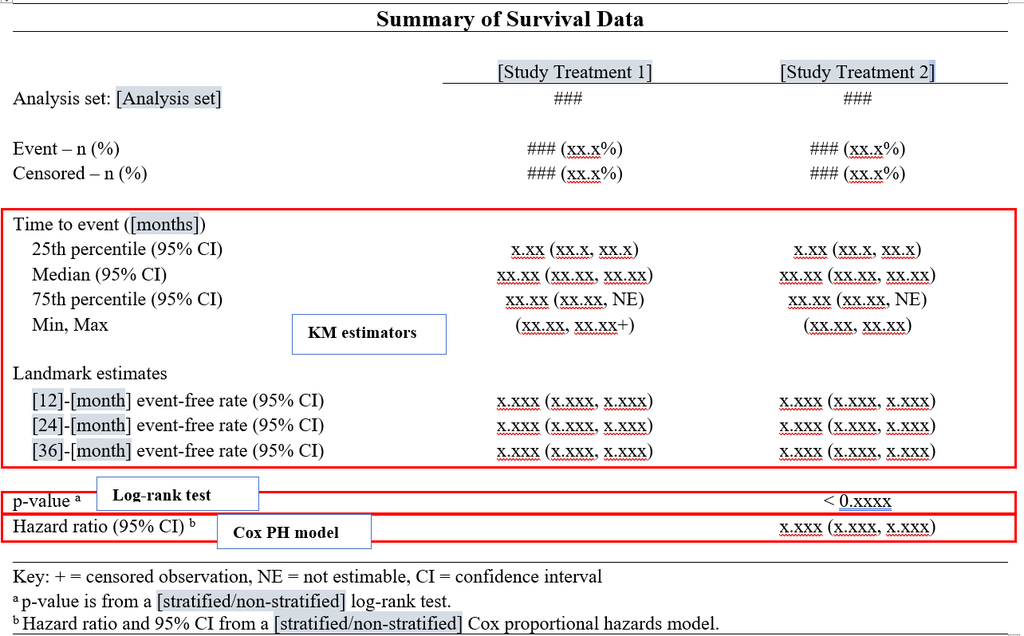

## Example data

Data source: https://stats.idre.ucla.edu/sas/seminars/sas-survival/

The data include 500 subjects from the Worcester Heart Attack Study. This study examined several factors, such as age, gender and BMI, that may influence survival time after heart attack. Follow up time for all participants begins at the time of hospital admission after heart attack and ends with death or loss to follow up (censoring). The variables used here are:

- lenfol: length of followup, terminated either by death or censoring - outcome variable
- fstat: the censoring variable, loss to followup=0, death=1
- afb: atrial fibrillation, no=0, 1=yes - explanatory variable
- gender: males=0, females=1 - stratification factor

Below shows the first 10 lines of data:

```
## # A tibble: 10 x 19
##       ID   AGE GENDER    HR SYSBP DIASBP   BMI   CVD   AFB   SHO   CHF   AV3
##    <dbl> <dbl>  <dbl> <dbl> <dbl>  <dbl> <dbl> <dbl> <dbl> <dbl> <dbl> <dbl>
##  1     1    83      0    89   152     78  25.5     1     1     0     0     0
##  2     2    49      0    84   120     60  24.0     1     0     0     0     0
##  3     3    70      1    83   147     88  22.1     0     0     0     0     0
##  4     4    70      0    65   123     76  26.6     1     0     0     1     0
##  5     5    70      0    63   135     85  24.4     1     0     0     0     0
##  6     6    70      0    76    83     54  23.2     1     0     0     0     1
##  7     7    57      0    73   191    116  39.5     1     0     0     0     0
##  8     8    55      0    91   147     95  27.1     1     0     0     0     0
##  9     9    88      1    63   209    100  27.4     1     0     0     1     0
## 10    10    54      0   104   166    106  25.5     1     0     0     0     0
## # ... with 7 more variables: MIORD <dbl>, MITYPE <dbl>, YEAR <dbl>, LOS <dbl>,
## #   DSTAT <dbl>, LENFOL <dbl>, FSTAT <dbl>
```

## R vs. SAS results

First we try a non-stratified analysis following the mockup above to describe the association between survival time and afb (atrial fibrillation).

Below are the R codes to produce the statistics in the mockup. The KM estimators are from `survival::survfit` function, the log-rank test uses `survminer::surv_pvalue`, and Cox PH model is conducted using `survival::coxph` function.

```r
# Data manipulation
## change afb order to use "Yes" as the reference group to be consistent with SAS
dat$AFB <- factor(dat$AFB, levels = c(1, 0))
## change follow-up days to years for a more intuitive display
dat$LENFOLY <- round(dat$LENFOL/365.25, 2)

# KM estimators
fit.km <- survfit(Surv(LENFOLY, FSTAT) ~ AFB, data = dat)
## quantile estimates
quantile(fit.km, probs = c(0.25, 0.5, 0.75))
```

```
## $quantile
##         25   50   75
## AFB=1 0.26 2.37 6.43
## AFB=0 0.94 5.91 6.44
##
## $lower
##         25   50   75
## AFB=1 0.05 1.27 4.24
## AFB=0 0.55 4.32 6.44
##
## $upper
##         25   50 75
## AFB=1 1.11 4.24 NA
## AFB=0 1.47   NA NA
```

```r
## landmark estimates at 1, 3, 5-year
summary(fit.km, times = c(1, 3, 5))
```

```
## Call: survfit(formula = Surv(LENFOLY, FSTAT) ~ AFB, data = dat)
##
##                 AFB=1
##  time n.risk n.event survival std.err lower 95% CI upper 95% CI
##     1     50      28    0.641  0.0543        0.543        0.757
##     3     27      12    0.455  0.0599        0.351        0.589
##     5     11       6    0.315  0.0643        0.211        0.470
##
##                 AFB=0
##  time n.risk n.event survival std.err lower 95% CI upper 95% CI
##     1    312     110    0.739  0.0214        0.699        0.782
##     3    199      33    0.642  0.0245        0.595        0.691
##     5     77      20    0.530  0.0311        0.472        0.595
```

```r
# Log-rank test from `survminer` package
survminer::surv_pvalue(fit.km, data = dat)
```

```
##   variable         pval   method    pval.txt
## 1      AFB 0.0009646027 Log-rank p = 0.00096
```

```r
# Cox PH model
fit.cox <- coxph(Surv(LENFOLY, FSTAT) ~ AFB, data = dat)
summary(fit.cox)
```

```
## Call:
## coxph(formula = Surv(LENFOLY, FSTAT) ~ AFB, data = dat)
##
##   n= 500, number of events= 215
##
##         coef exp(coef) se(coef)      z Pr(>|z|)
## AFB0 -0.5398    0.5829   0.1654 -3.263   0.0011 **
## ---
## Signif. codes:  0 '***' 0.001 '**' 0.01 '*' 0.05 '.' 0.1 ' ' 1
##
##      exp(coef) exp(-coef) lower .95 upper .95
## AFB0    0.5829      1.716    0.4214    0.8061
##
## Concordance= 0.537  (se = 0.014 )
## Likelihood ratio test= 9.59  on 1 df,   p=0.002
## Wald test            = 10.65  on 1 df,   p=0.001
## Score (logrank) test = 10.91  on 1 df,   p=0.001
```

Below are the SAS codes to produce the statistics in the mockup. The KM estimators and log-rank test are from `PROC LIFETEST`, and Cox PH model is conducted using `PROC PHREG`.

```r
# KM estimators and log-rank test
proc lifetest data=whas500;
time lenfoly*fstat(0);
strata /group = afb;
run;

# Cox PH model
proc phreg data = whas500;
class afb;
model lenfol*fstat(0) = afb/rl;
run;
```

Compare the results side-by-side, you could see that the CIs for the quantile estimates and landmark estimates are very different in the two software. HR and CI also have slight differences in third decimal.

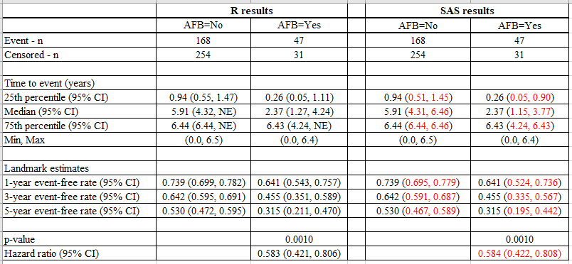

R vs. SAS - Non-stratified Analysis

There are three reasons for the differences:

1. Default methods for handling ties in Cox model are different: R uses “efron”, and SAS uses “breslow”. In fact, both options are available in both R and SAS, so by simply changing the default method, we would expect an identical HR and CI.
- R: change to “breslow”

```r
fit.cox <- coxph(Surv(LENFOLY, FSTAT) ~ AFB, ties = "breslow", data = dat)
```

- SAS: change to “efron”

```r
proc phreg data = whas500;
class afb;
model lenfol*fstat(0) = afb/rl ties = efron;
run;
```

From the arguments of `coxph`: There are three possible choices for handling tied event times. The Breslow approximation is the easiest to program and hence became the first option coded for almost all computer routines. It then ended up as the default option when other options were added in order to “maintain backwards compatability”. The Efron option is more accurate if there are a large number of ties, and it is the default option here. In practice the number of ties is usually small, in which case all the methods are statistically indistinguishable.

2. Default methods for confidence intervals of the KM estimates are different: R uses “log”, and SAS uses “log-log”. Again, R and SAS have both options.
- R: change to “log-log”

```r
fit.km <- survfit(Surv(LENFOLY, FSTAT) ~ AFB, conf.type = "log-log", data = dat)
```

- SAS: change to “log”

```r
proc lifetest data=whas500 conftype = log;
time lenfoly*fstat(0);
strata /group = afb;
run;
```

“log-log” prevents the problem of having confidence intervals of >1 or <0, which might happen if using “log” transformation. However, both R and SAS will clip the interval at [0, 1] and report a bound >1 as 1 and <0 as 0.

From a [reference](https://myweb.uiowa.edu/pbreheny/7210/f15/notes/9-10.pdf): The appeal of the log-log interval is clear, but the log-scale interval has the advantage of variance stabilization. As a result, simulation studies have generally found it to have better (closer to nominal) coverage; for this reason, it is the default in the `survival` package.

3. The third reason is a little bit complicated, to explain it, let’s first take a look at the results if we change the default methods in R to match SAS.

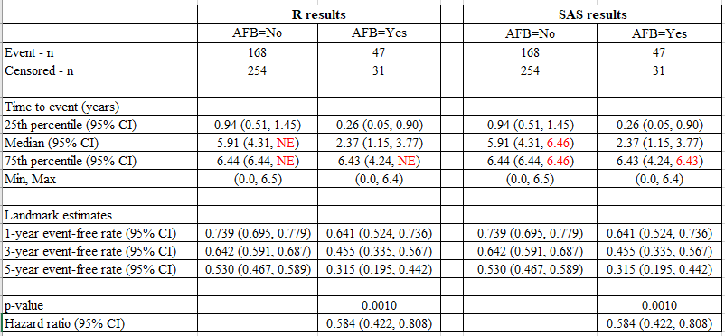

R vs. SAS - Non-stratified Analysis after Changing Default Methods for Tie Handling and CI Calculation in R

After changing the two default methods, all match except the upper limits of median and 75% quantile in “AFB=No” arm and 75% quantile in “AFB=Yes” arm. R show “NE - not estimable” for all three, while SAS give some values.

We’ll use the KM curve of “AFB=No” arm to illustrate how the kth quantile and CI are calculated.

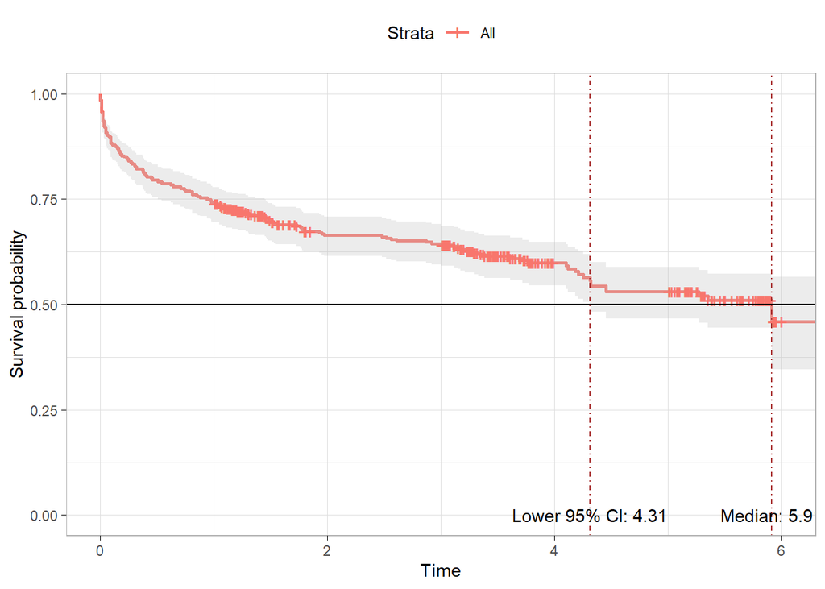

```r
fit.km.no <- survfit(Surv(LENFOLY, FSTAT) ~ 1, conf.type = "log-log", data = dat[dat$AFB == 0, ])
pl <- survminer::ggsurvplot(fit.km.no,
                            conf.int = TRUE,
                            ggtheme = theme_light())
pl$plot +  geom_hline(yintercept = 0.5, color = "black", linetype = "solid") +
  geom_vline(xintercept = 5.91, color = "brown", linetype = "dotdash") +
  annotate("text", x = 5.91, y = 0, label = "Median: 5.91") +
  geom_vline(xintercept = 4.31, color = "brown", linetype = "dotdash") +
  annotate("text", x = 4.31, y = 0, label = "Lower 95% CI: 4.31")
```

The kth quantile for a survival curve is the location at which a horizontal line at height p = 1-k intersects the plot of survival probability. If the survival curve does not fall to 1-k, then that quantile is undefined. Similarly, confidence limits for the values are based on the intersection of the horizontal line at 1-k with the upper and lower limits for the survival curve.

For example, if we look at the survival estimates in the KM curve for the following timepoints:

- The median is the smallest time which survival estimate is <= 0.5 –> 5.91
- The 95% lower bound of the median is the smallest time which lower 95% CI is <= 0.5 –> 4.31
- The 95% lower bound of the median is the smallest time which upper 95% CI is <= 0.5 –> no upper CI <= 0.5, so upper bound is not estimable “NE”.

```r
summary(fit.km.no, times = c(4.21, 4.25, 4.31, 4.32, 4.45, 5.27, 5.35, 5.91, 6.44, 6.46))
```

```
## Call: survfit(formula = Surv(LENFOLY, FSTAT) ~ 1, data = dat[dat$AFB ==
##     0, ], conf.type = "log-log")
##
##  time n.risk n.event survival std.err lower 95% CI upper 95% CI
##  4.21     84     157    0.571  0.0286       0.5132        0.625
##  4.25     83       1    0.564  0.0291       0.5054        0.619
##  4.31     82       1    0.557  0.0295       0.4976        0.613
##  4.32     81       2    0.544  0.0304       0.4823        0.601
##  4.45     79       2    0.530  0.0311       0.4672        0.589
##  5.27     58       1    0.521  0.0319       0.4565        0.581
##  5.35     50       1    0.510  0.0329       0.4442        0.573
##  5.91     10       1    0.459  0.0568       0.3458        0.566
##  6.44      2       1    0.230  0.1649       0.0218        0.568
##  6.46      1       1    0.000     NaN           NA           NA
```

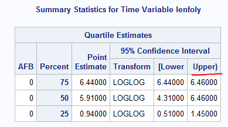

```r
test1 <- dat %>% mutate(FSTAT = ifelse(LENFOLY > 6.42, 0, FSTAT))
```

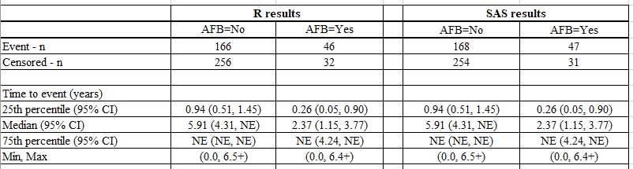

## Stratified analysis

- R codes

```r
# KM estimators
fit.km <- survfit(Surv(LENFOLY, FSTAT) ~ AFB + strata(GENDER), data = dat)
## quantile estimates
quantile(fit.km, probs = c(0.25, 0.5, 0.75))
## landmark estimates at 1, 3, 5-year
summary(fit.km, times = c(1, 3, 5))

# Log-rank test from `survminer` package
survminer::surv_pvalue(fit.km, data = dat)

# Cox PH model
fit.cox <- coxph(Surv(LENFOLY, FSTAT) ~ AFB + strata(GENDER), data = dat)
summary(fit.cox)
```

- SAS codes

```r
# KM estimators and log-rank test
proc lifetest data=whas500;
time lenfoly*fstat(0);
strata gender/group = afb;
run;

# Cox PH model
proc phreg data = whas500;
class afb;
model lenfol*fstat(0) = afb/rl;
strata gender;
run;
```

# Other cases

Suppose a dataset with 10 observations, and the first 5 are all events, and the last 5 are all censored.

```r
test2 <- data.frame(TIME = c(54, 75, 77, 84, 87, 92, 103, 105, 112, 118), CNSR = c(1, 1, 1, 1, 1, 0, 0, 0, 0, 0))

# KM estimators
fit.km <- survfit(Surv(TIME, CNSR) ~ 1, conf.type = "log-log", data = test2)
## quantile estimates
quantile(fit.km, probs = c(0.25, 0.5, 0.75))
## landmark estimates at 80, 100, 120-day
summary(fit.km, times = c(80, 100, 120), extend = T)
```

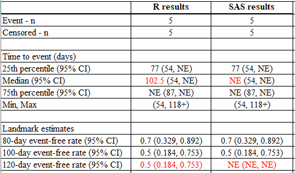

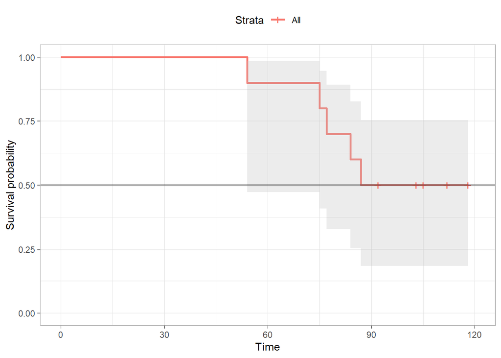

[output not shown]

1. The kth quantile for a survival curve S(t) is the location at which a horizontal line at height p= 1-k intersects the plot of S(t). Since S(t) is a step function, it is possible for the curve to have a horizontal segment at exactly 1-k, in which case the midpoint of the horizontal segment is returned:

The median is the smallest time which survival estimate is <= 0.5 –> `(87+118) / 2 = 102.5`

However, SAS searches the smallest time which survival estimate is < 0.5, which does not exist in this dataset, so it gives “NE”.

2. For the 120-day event-free estimate, 120-day is beyond the maximum observed day, since it is unknown, SAS gives “NE”, but R uses the rate at last observed censored date to estimate the 120-day event free rate.

However, if change the last observation to be an event, R and SAS will both give 0 because it is certain that all subjects did not survival beyond 120 days.

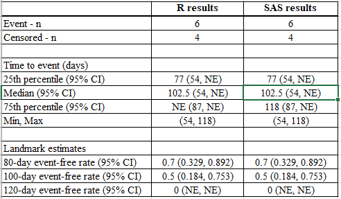

# Parametric model

We found that a poorly fit generalized gamma have better AIC in comparison with other distribution like gompertz. It doesn’t give any warning message about convergence. I’ve enclosed a sample data to demonstrate this example.

It is common for the generalized gamma model to not converge. There are ways to try and make it converge. However, this involves making transformations to time which means that we then cannot compare it with other models using AIC and BIC.

However, I think this is more likely to be the error of plotting the predicted curve in R.

```r
gompz <-  flexsurvreg(Surv(t,flag) ~ 1,dist="gompertz",data=tmp)
ggamma <- flexsurvreg(Surv(t,flag) ~ 1,dist="gengamma",data=tmp)
rbind(gompz[c('AIC','loglik','npars')],
     ggamma[c('AIC','loglik','npars')])
     AIC      loglik    npars
[1,] 558.9885 -277.4942 2
[2,] 520.3229 -257.1614 3
```

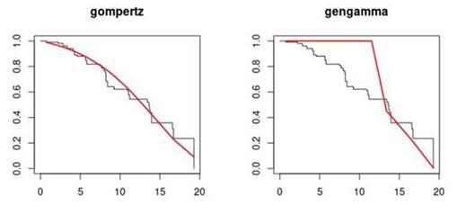

# References

Breslow, N. E. (1974) “Covariance Analysis of Censored Survival Data.” Biometrics 30:89–99.

Efron, B. (1977. “The Efficiency of Cox’s Likelihood Function for Censored Data.” Journal of the American Statistical Association 72:557–565.

Hertz-Picciotto I. and Rockhill B. (1997) “Validity and efficiency of approximation methods for tied survival times in Cox regression.” Biometrics 53:1151-1156.

Hosmer, D.W. and Lemeshow, S. and May, S. (2008) “Applied Survival Analysis: Regression Modeling of Time to Event Data: Second Edition.” John Wiley and Sons Inc., New York, NY

[SAS PROC LIFETEST Documentation](https://documentation.sas.com/doc/en/statug/15.2/statug_lifetest_details03.htm)